# Supervised Learning

## DOMAIN: Medical

### CONTEXT: Medical research university X is undergoing a deep research on patients with certain conditions. University has an internal AI team. Due to confidentiality the patient’s details and the conditions are masked by the client by providing different datasets to the AI team for developing a AIML model which can predict the condition of the patient depending on the received test results.

### DATA DESCRIPTION: The data consists of biomechanics features of the patients according to their current conditions. Each patient is represented in the data set by six biomechanics attributes derived from the shape and orientation of the condition to their body part.

### PROJECT OBJECTIVE: To Demonstrate the ability to fetch, process and leverage data to generate useful predictions by training Supervised Learning algorithms.

## 1. Data Understanding: [5 Marks]

```python
import pandas as pd
import numpy as np
import seaborn as sns
import matplotlib.pyplot as plt
from scipy import stats
%matplotlib inline
```

### 1.A. Read all the 3 CSV files as DataFrame and store them into 3 separate variables.

```python
nm=pd.read_csv('Normal.csv')
th=pd.read_csv('Type_H.csv')
ts=pd.read_csv('Type_S.csv')
```

```python
print('Normal: \n',nm.head())
print('Type_H:\n',th.head())
print('Type_S:\n',ts.head())
```

```
Normal:
    P_incidence     P_tilt    L_angle    S_slope    P_radius  S_Degree   Class
0    38.505273  16.964297  35.112814  21.540976  127.632875  7.986683  Normal
1    54.920858  18.968430  51.601455  35.952428  125.846646  2.001642  Normal
2    44.362490   8.945435  46.902096  35.417055  129.220682  4.994195  Normal
3    48.318931  17.452121  48.000000  30.866809  128.980308 -0.910941  Normal
4    45.701789  10.659859  42.577846  35.041929  130.178314 -3.388910  Normal
Type_H:
    P_incidence     P_tilt    L_angle    S_slope    P_radius   S_Degree   Class
0    63.027817  22.552586  39.609117  40.475232   98.672917  -0.254400  Type_H
1    39.056951  10.060991  25.015378  28.995960  114.405425   4.564259  Type_H
2    68.832021  22.218482  50.092194  46.613539  105.985135  -3.530317  Type_H
3    69.297008  24.652878  44.311238  44.644130  101.868495  11.211523  Type_H
4    49.712859   9.652075  28.317406  40.060784  108.168725   7.918501  Type_H
Type_S:
    P_incidence     P_tilt    L_angle    S_slope    P_radius   S_Degree   Class
0    74.377678  32.053104  78.772013  42.324573  143.560690  56.125906  Type_S
1    89.680567  32.704435  83.130732  56.976132  129.955476  92.027277  Type_S
2    44.529051   9.433234  52.000000  35.095817  134.711772  29.106575  Type_S
3    77.690577  21.380645  64.429442  56.309932  114.818751  26.931841  Type_S
4    76.147212  21.936186  82.961502  54.211027  123.932010  10.431972  Type_S
```

### 1.B. Print Shape and columns of all the 3 DataFrames.

```python
print('Shape of Normal', nm.shape)
print('Shape of Type_H', th.shape)
print('Shape of Type_S', ts.shape ,'\n')
print(nm.columns)
print(th.columns)
print(ts.columns)
```

```
Shape of Normal (100, 7)
Shape of Type_H (60, 7)
Shape of Type_S (150, 7)

Index(['P_incidence', 'P_tilt', 'L_angle', 'S_slope', 'P_radius', 'S_Degree',
       'Class'],
      dtype='object')
Index(['P_incidence', 'P_tilt', 'L_angle', 'S_slope', 'P_radius', 'S_Degree',
       'Class'],
      dtype='object')
Index(['P_incidence', 'P_tilt', 'L_angle', 'S_slope', 'P_radius', 'S_Degree',
       'Class'],
      dtype='object')
```

### 1.C. Compare Column names of all the 3 DataFrames and clearly write observations.

As per the above observation we can conclude all the three data frames has same columns names.

The first 6 columns represents shape and orientation of the body part.

The Last column "Class" seems to represent the condition of the organ based on the first 6 attributes and each dataframe having details related to respective Class names.

### 1.D. Print DataTypes of all the 3 DataFrames.

```python
print('\n Data types of Normal \n')
print(nm.info())
print('\n Data types of Type_H \n')
print(th.info())
print('\n Data types of Type_S \n')
print(ts.info())
```

```
 Data types of Normal

<class 'pandas.core.frame.DataFrame'>
RangeIndex: 100 entries, 0 to 99
Data columns (total 7 columns):
 #   Column       Non-Null Count  Dtype
---  ------       --------------  -----
 0   P_incidence  100 non-null    float64
 1   P_tilt       100 non-null    float64
 2   L_angle      100 non-null    float64
 3   S_slope      100 non-null    float64
 4   P_radius     100 non-null    float64
 5   S_Degree     100 non-null    float64
 6   Class        100 non-null    object
dtypes: float64(6), object(1)
memory usage: 5.6+ KB
None

 Data types of Type_H

<class 'pandas.core.frame.DataFrame'>
RangeIndex: 60 entries, 0 to 59
Data columns (total 7 columns):
 #   Column       Non-Null Count  Dtype
---  ------       --------------  -----
 0   P_incidence  60 non-null     float64
 1   P_tilt       60 non-null     float64
 2   L_angle      60 non-null     float64
 3   S_slope      60 non-null     float64
 4   P_radius     60 non-null     float64
 5   S_Degree     60 non-null     float64
 6   Class        60 non-null     object
dtypes: float64(6), object(1)
memory usage: 3.4+ KB
None

 Data types of Type_S

<class 'pandas.core.frame.DataFrame'>
RangeIndex: 150 entries, 0 to 149
Data columns (total 7 columns):
 #   Column       Non-Null Count  Dtype
---  ------       --------------  -----
 0   P_incidence  150 non-null    float64
 1   P_tilt       150 non-null    float64
 2   L_angle      150 non-null    float64
 3   S_slope      150 non-null    float64
 4   P_radius     150 non-null    float64
 5   S_Degree     150 non-null    float64
 6   Class        150 non-null    object
dtypes: float64(6), object(1)
memory usage: 8.3+ KB
None
```

### 1.E. Observe and share variation in ‘Class’ feature of all the 3 DaraFrames

```python
print('Unique values in Class feature of nm dataframe:',nm['Class'].unique())
print('Unique values in Class feature of th dataframe',th['Class'].unique())
print('Unique values in Class feature of ts dataframe',ts['Class'].unique())
```

```
Unique values in Class feature of nm dataframe: ['Normal' 'Nrmal']
Unique values in Class feature of th dataframe ['Type_H' 'type_h']
Unique values in Class feature of ts dataframe ['Type_S' 'tp_s']
```

#### Class has been represented with different terminologies in all three dataframes.

Under nm dataframe "Class" is labled with "Normal" and "Nrmal"

Under th dataframe "Class" is labled with "Type_H" and "type_h"

Under th dataframe "Class" is labled with "Type_S" and "tp_s"

## 2. Data Preparation and Exploration: [5 Marks]

### 2.A. Unify all the variations in ‘Class’ feature for all the 3 DataFrames.

For Example: ‘tp_s’, ‘Type_S’, ‘type_s’ should be converted to ‘type_s’

```python
nm['Class']= nm['Class'].replace('Nrmal','Normal')
th['Class']= th['Class'].replace('Type_H','type_h')
ts['Class']= ts['Class'].replace(['Type_S', 'tp_s'],'type_s')
```

```python
print('Unique values in Class feature of nm dataframe',nm['Class'].unique())
print('Unique values in Class feature of th dataframe',th['Class'].unique())
print('Unique values in Class feature of ts dataframe',ts['Class'].unique())
```

```
Unique values in Class feature of nm dataframe ['Normal']
Unique values in Class feature of th dataframe ['type_h']
Unique values in Class feature of ts dataframe ['type_s']
```

### 2.B. Combine all the 3 DataFrames to form a single DataFrame

Checkpoint: Expected Output shape = (310,7)

```python
nhs=pd.concat([nm,th,ts])
nhs.shape
```

```
(310, 7)
```

### 2.C. Print 5 random samples of this DataFrame

```python
nhs.sample(5)
```

|  | P_incidence | P_tilt | L_angle | S_slope | P_radius | S_Degree | Class |
| --- | --- | --- | --- | --- | --- | --- | --- |
| 137 | 58.828379 | 37.577873 | 125.742385 | 21.250506 | 135.629418 | 117.314683 | type_s |
| 44 | 72.955644 | 19.576971 | 61.007071 | 53.378673 | 111.234047 | 0.813491 | Normal |
| 24 | 76.326002 | 42.396204 | 57.200000 | 33.929797 | 124.267007 | 50.127457 | type_s |
| 84 | 60.044177 | 14.309656 | 58.038865 | 45.734521 | 105.131664 | 30.409133 | type_s |
| 12 | 48.915551 | 19.964556 | 40.263794 | 28.950995 | 119.321358 | 8.028895 | type_h |

### 2.D. Print Feature-wise percentage of Null values.

```python
print('Feature-wise percentage of Null values.\n',(nhs.isnull().sum()/len(nhs))*100)
```

```
Feature-wise percentage of Null values.
 P_incidence    0.0
P_tilt         0.0
L_angle        0.0
S_slope        0.0
P_radius       0.0
S_Degree       0.0
Class          0.0
dtype: float64
```

### 2.E. Check 5-point summary of the new DataFrame.

```python
nhs.describe().loc[['min', '25%', '50%', '75%', 'max']]
```

|  | P_incidence | P_tilt | L_angle | S_slope | P_radius | S_Degree |
| --- | --- | --- | --- | --- | --- | --- |
| min | 26.147921 | -6.554948 | 14.000000 | 13.366931 | 70.082575 | -11.058179 |
| 25% | 46.430294 | 10.667069 | 37.000000 | 33.347122 | 110.709196 | 1.603727 |
| 50% | 58.691038 | 16.357689 | 49.562398 | 42.404912 | 118.268178 | 11.767934 |
| 75% | 72.877696 | 22.120395 | 63.000000 | 52.695888 | 125.467674 | 41.287352 |
| max | 129.834041 | 49.431864 | 125.742385 | 121.429566 | 163.071041 | 418.543082 |

## 3. Data Analysis [10 Marks]

### 3.A. Visualize a heatmap to understand correlation between all features [2 Marks]

```
C:\Users\Bharath kumar s\AppData\Local\Temp\ipykernel_18996\2385267134.py:1: FutureWarning: The default value of numeric_only in DataFrame.corr is deprecated. In a future version, it will default to False. Select only valid columns or specify the value of numeric_only to silence this warning.
  sns.heatmap(nhs.corr(),annot=True)
```

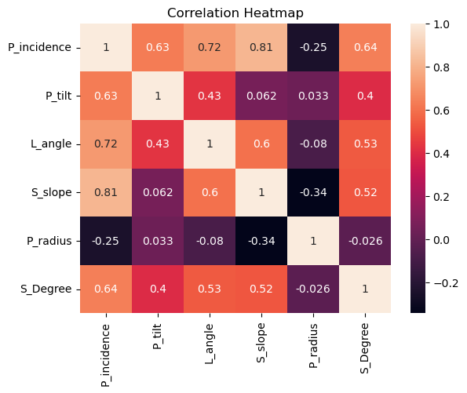

```python
sns.heatmap(nhs.corr(),annot=True)
plt.yticks(rotation = 0)
plt.xticks(rotation = 90)
plt.title('Correlation Heatmap')
plt.show()
```

### 3.B. Share insights on correlation.

A. Features having stronger correlation with correlation value.  
B. Features having weaker correlation with correlation value

#### Obervations from Heat map

P_incidence has good positive correlation with S_degree, S_Slope, P_tilt, L_angle

S_Slope and P_incidence has highest positive correlation of 0.81

P_radius is negetively corelated with all other attributes except P_tilt

S_Slope and P_radius has highest negetive corelation score of -0.34

### 3.C. Visualize a pairplot with 3 classes distinguished by colors and share insights.

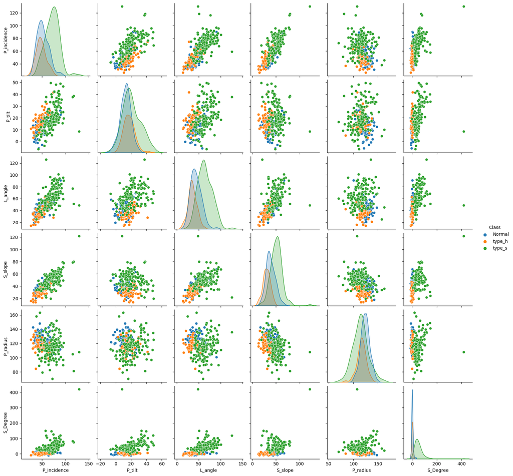

```python
sns.pairplot(nhs,hue='Class',diag_kind= 'kde')
```

#### Observations

type_s has higher spread when compared type_h and normal

type_s seems to have outliers with respect to most of the attributes

S_Degree seems to be higly right skewed

### 3.D. Visualize a jointplot for ‘P_incidence’ and ‘S_slope’ and share insights.

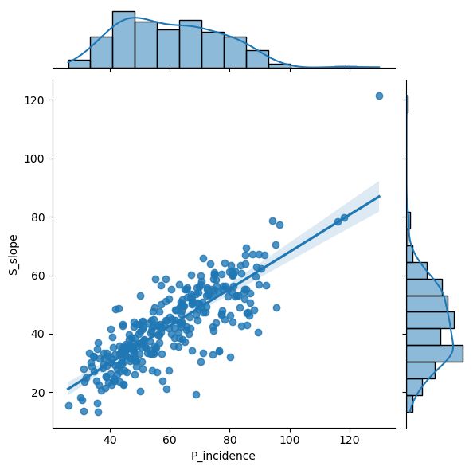

```python
sns.jointplot(data=nhs,x='P_incidence',y='S_slope',kind='reg')
```

#### Observations

‘P_incidence’ and ‘S_slope’ seems to be positively corelated (backed by the heat map earlier as well)

The data seems to have almost linear distribution

### 3.E. Visualize a boxplot to check distribution of the features and share insights.

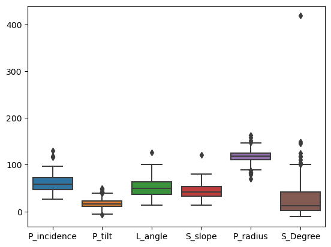

```python
sns.boxplot(nhs)
```

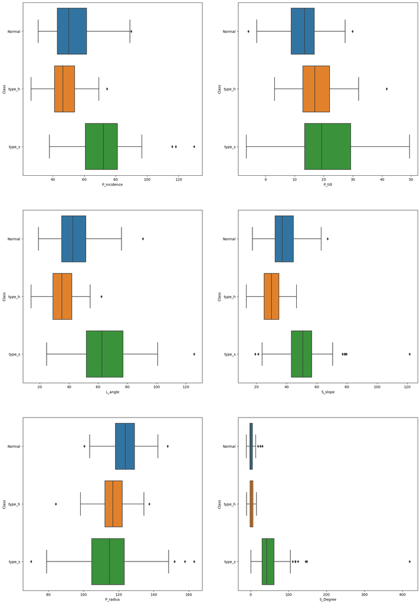

```python
fig, ax = plt.subplots(3,2, figsize=(20,30))
Columns = ['P_incidence','P_tilt','L_angle','S_slope','P_radius','S_Degree']
len_Columns = len(Columns)
index = 0
for j in range(len(ax)):
    for i in range(len(ax[j])):
        if(index < len_Columns):
            ax[j][i] = sns.boxplot(x=nhs[Columns[index]],y=nhs['Class'],ax = ax[j][i])
            index = index + 1
```

##### Observations :

From the first box plot we can see that there are outliers in all the features

S_Degree seems to have an extreme outlier

L_angle and S_Slope has only one outliers each

In the second set of box plot each features are plotted against the 'Class'

As mentioned previously 'type_s' has higher spread when compared to 'Normal' and 'type_h' Class.

Extream outlier in S_Degree is from the Type_S class

Extream outliers if not handled could cause irregularities in the prediction model

##### Outlier Treatment by replacing outliers with mean

```python
    for c in Columns:
        q25,q75=np.percentile(nhs[c],25),np.percentile(nhs[c],75)
        IQR=q75-q25
        Threshold=IQR*1.5
        lower,upper=q25-Threshold,q75+Threshold
        Outliers=[i for i in nhs[c] if i < lower or i > upper]
        print('Total Number of outliers in Before Imputing :',len(Outliers))
        print('\n')
        df_include = nhs.loc[(nhs[c] >= lower) & (nhs[c] <= upper)]
        mean=int(df_include[c].mean())
        print('Mean of is ',mean)
        print('\n')
        nhs[c]=np.where(nhs[c]>upper,mean,nhs[c])
        nhs[c]=np.where(nhs[c]<lower,mean,nhs[c])
        Outliers=[i for i in nhs[c] if i < lower or i > upper]
        print('Total Number of outliers in After Imputing :',len(Outliers))
        print('\n')
```

```
Total Number of outliers in Before Imputing : 3


Mean of is  59


Total Number of outliers in After Imputing : 0


Total Number of outliers in Before Imputing : 13


Mean of is  16


Total Number of outliers in After Imputing : 0


Total Number of outliers in Before Imputing : 1


Mean of is  51


Total Number of outliers in After Imputing : 0


Total Number of outliers in Before Imputing : 1


Mean of is  42


Total Number of outliers in After Imputing : 0


Total Number of outliers in Before Imputing : 11


Mean of is  118


Total Number of outliers in After Imputing : 0


Total Number of outliers in Before Imputing : 10


Mean of is  22


Total Number of outliers in After Imputing : 0
```

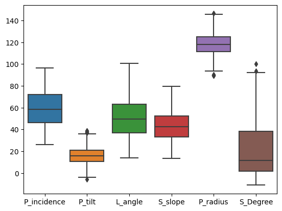

```python
sns.boxplot(nhs)
```

## 4. Model Building:

### 4.A. Split data into X and Y.

```python
X=nhs.drop(columns='Class')
Y=nhs['Class']
```

```python
print('X \n', X.sample(5),'\n')
print('Y \n',Y.sample(5))
```

```
X
      P_incidence     P_tilt    L_angle    S_slope    P_radius   S_Degree
102    59.000000  38.449501  50.838520  79.695154  118.000000  74.043767
54     80.988074  36.843172  86.960602  44.144903  141.088149  85.872152
0      63.027817  22.552586  39.609117  40.475232   98.672917  -0.254400
61     42.515610  16.541216  42.000000  25.974394  120.631941   7.876731
96     79.476978  26.732268  70.650982  52.744711  118.588669  61.700598

Y
 52    type_h
40    type_h
55    type_h
4     type_h
74    type_s
Name: Class, dtype: object
```

### 4.B. Split data into train and test with 80:20 proportion.

```python
from sklearn.model_selection import train_test_split
X_train, X_test, y_train, y_test = train_test_split(X,Y,test_size=0.20,random_state=10)
```

```python
print(nhs.shape)
print(X_train.shape)
print(X_test.shape)
```

```
(310, 7)
(248, 6)
(62, 6)
```

### 4.C. Train a Supervised Learning Classification base model using KNN classifier

```python
from sklearn.neighbors import KNeighborsClassifier
NNH=KNeighborsClassifier(n_neighbors=5, metric ='euclidean')
NNH.fit(X_train, y_train)
```

```
KNeighborsClassifier(metric='euclidean')
```

```python
predicted_labels = NNH.predict(X_test)
print('Acurracy score on Trining data',NNH.score(X_train, y_train))
print('Acurracy score on Testing data',NNH.score(X_test, y_test))
```

```
Acurracy score on Trining data 0.9153225806451613
Acurracy score on Testing data 0.7096774193548387
```

```
Confusion Matrix
```

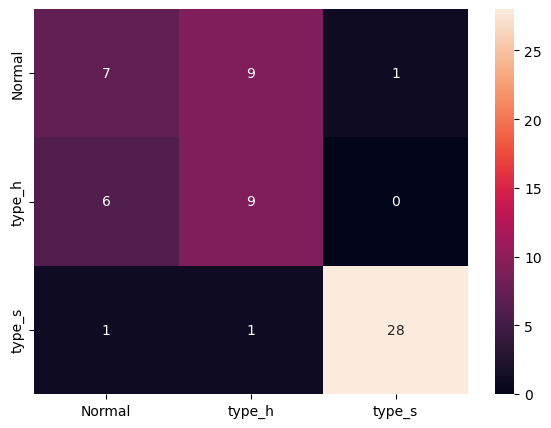

```python
from sklearn import metrics

print("Confusion Matrix")
cm=metrics.confusion_matrix(y_test, predicted_labels, labels=["Normal", "type_h","type_s"])

nhs_cm = pd.DataFrame(cm, index = [i for i in ["Normal", "type_h","type_s"]],
                  columns = [i for i in ["Normal", "type_h","type_s"]])
plt.figure(figsize = (7,5))
sns.heatmap(nhs_cm, annot=True)
```

```python
from sklearn.metrics import classification_report
print("classification  Matrix:\n",classification_report(y_test,predicted_labels))
```

```
classification  Matrix:
               precision    recall  f1-score   support

      Normal       0.50      0.41      0.45        17
      type_h       0.47      0.60      0.53        15
      type_s       0.97      0.93      0.95        30

    accuracy                           0.71        62
   macro avg       0.65      0.65      0.64        62
weighted avg       0.72      0.71      0.71        62
```

## 5. Performance Improvement:

### 5.A. Experiment with various parameters to improve performance of the base model.

(Optional: Experiment with various Hyperparameters - Research required)

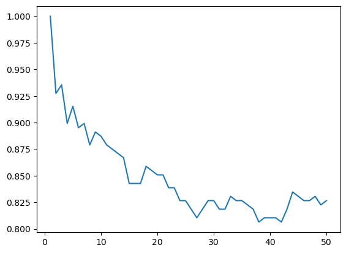

```python
train_score=[]
test_score=[]
for k in range(1,51):
    KNN = KNeighborsClassifier(n_neighbors= k , metric ='euclidean' )
    KNN.fit(X_train, y_train)
    train_score.append(KNN.score(X_train, y_train))
    test_score.append(KNN.score(X_test, y_test))
plt.plot(range(1,51),train_score)
plt.show()
```

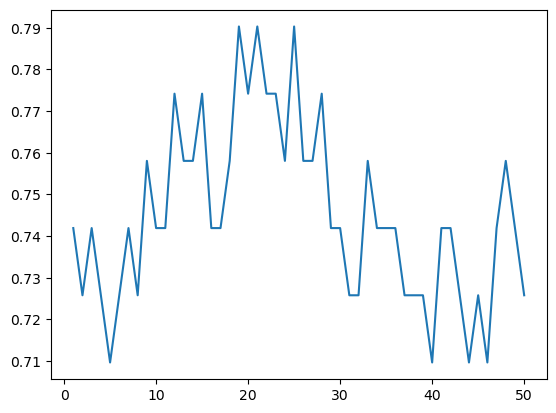

```python
plt.plot(range(1,51),test_score)
plt.show()
```

**Experiment with various Hyperparameters - Research required**

```python
from sklearn.model_selection import GridSearchCV
grid_params = { 'n_neighbors' : [5,7,9,11,13,15],
               'weights' : ['uniform','distance'],
               'metric' : ['minkowski','euclidean','manhattan']}
model = KNeighborsClassifier(n_jobs=-1)
model1 = GridSearchCV(model, param_grid=grid_params, n_jobs=1)
model1.fit(X_train,y_train)
print("Best Hyper Parameters:\n",model1.best_params_)
prediction=model1.predict(X_test)
from sklearn import metrics
print("Accuracy:",metrics.accuracy_score(prediction,y_test))
```

```
Best Hyper Parameters:
 {'metric': 'manhattan', 'n_neighbors': 9, 'weights': 'distance'}
Accuracy: 0.7580645161290323
```

### 5.B.Clearly showcase improvement in performance achieved.

For Example:

A. Accuracy: +15% improvement

B. Precision: +10% improvement

```python
from sklearn.metrics import classification_report
print("classification  Matrix before Hyperparameter tuning:\n",classification_report(y_test,predicted_labels))
```

```
classification  Matrix before Hyperparameter tuning:
               precision    recall  f1-score   support

      Normal       0.50      0.41      0.45        17
      type_h       0.47      0.60      0.53        15
      type_s       0.97      0.93      0.95        30

    accuracy                           0.71        62
   macro avg       0.65      0.65      0.64        62
weighted avg       0.72      0.71      0.71        62
```

```python
NNH_m=KNeighborsClassifier(n_neighbors=9, metric ='manhattan',weights='distance')
NNH_m.fit(X_train, y_train)
predicted_labels_m = NNH_m.predict(X_test)
print("classification  Matrix post before Hyperparameter tuning :\n",classification_report(y_test,predicted_labels_m))
```

```
classification  Matrix post before Hyperparameter tuning :
               precision    recall  f1-score   support

      Normal       0.60      0.53      0.56        17
      type_h       0.56      0.67      0.61        15
      type_s       0.97      0.93      0.95        30

    accuracy                           0.76        62
   macro avg       0.71      0.71      0.71        62
weighted avg       0.77      0.76      0.76        62
```

**Accurecy increased from .71 to .76**

### 5.C. Clearly state which parameters contributed most to improve model performance.

##### Parameters.

The Kvalue and the metric contributed most to improve model performance

##### Improvements

The Data related to the patient is limited and could include other features such as medical history and previous conditions to increase the accuracy of the models

# Part B

## DOMAIN: Banking, Marketing

### CONTEXT : A bank X is on a massive digital transformation for all its departments. Bank has a growing customer base whee majority of them are liability customers (depositors) vs borrowers (asset customers). The bank is interested in expanding the borrowers base rapidly to bring in more business via loan interests. A campaign that the bank ran in last quarter showed an average single digit conversion rate. Digital transformation being the core strength of the business strategy, marketing department wants to devise effective campaigns with better target marketing to increase the conversion ratio to double digit with same budget as per last campaign.

### • DATA DICTIONARY:

**1. ID: Customer ID

1. Age: Customer’s approximate age.
2. CustomerSince: Customer of the bank since. [unit is masked]
3. HighestSpend: Customer’s highest spend so far in one transaction. [unit is masked]
4. ZipCode: Customer’s zip code.
5. HiddenScore: A score associated to the customer which is masked by the bank as an IP.
6. MonthlyAverageSpend: Customer’s monthly average spend so far. [unit is masked]
7. Level: A level associated to the customer which is masked by the bank as an IP.
8. Mortgage: Customer’s mortgage. [unit is masked]
9. Security: Customer’s security asset with the bank. [unit is masked]
10. FixedDepositAccount: Customer’s fixed deposit account with the bank. [unit is masked]
11. InternetBanking: if the customer uses internet banking.
12. CreditCard: if the customer uses bank’s credit card.
13. LoanOnCard: if the customer has a loan on credit card  
    **

### • PROJECT OBJECTIVE:

**Build a Machine Learning model to perform focused marketing by predicting the potential customers who will convert using the historical dataset**

### 1.Data Understanding and Preparation:

### 1.A. Read both the Datasets ‘Data1’ and ‘Data 2’ as DataFrame and store them into two separate variables.

```python
df1=pd.read_csv('Data1.csv')
df2=pd.read_csv('Data2.csv')
print( df1.info())
print( df2.info())
```

```
<class 'pandas.core.frame.DataFrame'>
RangeIndex: 5000 entries, 0 to 4999
Data columns (total 8 columns):
 #   Column               Non-Null Count  Dtype
---  ------               --------------  -----
 0   ID                   5000 non-null   int64
 1   Age                  5000 non-null   int64
 2   CustomerSince        5000 non-null   int64
 3   HighestSpend         5000 non-null   int64
 4   ZipCode              5000 non-null   int64
 5   HiddenScore          5000 non-null   int64
 6   MonthlyAverageSpend  5000 non-null   float64
 7   Level                5000 non-null   int64
dtypes: float64(1), int64(7)
memory usage: 312.6 KB
None
<class 'pandas.core.frame.DataFrame'>
RangeIndex: 5000 entries, 0 to 4999
Data columns (total 7 columns):
 #   Column               Non-Null Count  Dtype
---  ------               --------------  -----
 0   ID                   5000 non-null   int64
 1   Mortgage             5000 non-null   int64
 2   Security             5000 non-null   int64
 3   FixedDepositAccount  5000 non-null   int64
 4   InternetBanking      5000 non-null   int64
 5   CreditCard           5000 non-null   int64
 6   LoanOnCard           4980 non-null   float64
dtypes: float64(1), int64(6)
memory usage: 273.6 KB
None
```

```python
print('df1 Head \n', df1.head())
print('df2 Head \n', df2.head())
```

```
df1 Head
    ID  Age  CustomerSince  HighestSpend  ZipCode  HiddenScore  \
0   1   25              1            49    91107            4
1   2   45             19            34    90089            3
2   3   39             15            11    94720            1
3   4   35              9           100    94112            1
4   5   35              8            45    91330            4

   MonthlyAverageSpend  Level
0                  1.6      1
1                  1.5      1
2                  1.0      1
3                  2.7      2
4                  1.0      2
df2 Head
    ID  Mortgage  Security  FixedDepositAccount  InternetBanking  CreditCard  \
0   1         0         1                    0                0           0
1   2         0         1                    0                0           0
2   3         0         0                    0                0           0
3   4         0         0                    0                0           0
4   5         0         0                    0                0           1

   LoanOnCard
0         NaN
1         NaN
2         NaN
3         NaN
4         NaN
```

### 1.B. Print shape and Column Names and DataTypes of both the Dataframes.

```python
print('df1 Shape', df1.shape)
print('df1 Columns', df1.columns)
```

```
df1 Shape (5000, 8)
df1 Columns Index(['ID', 'Age', 'CustomerSince', 'HighestSpend', 'ZipCode', 'HiddenScore',
       'MonthlyAverageSpend', 'Level'],
      dtype='object')
```

```python
print('df2 Shape', df2.shape)
print('df2 Columns', df2.columns)
```

```
df2 Shape (5000, 7)
df2 Columns Index(['ID', 'Mortgage', 'Security', 'FixedDepositAccount', 'InternetBanking',
       'CreditCard', 'LoanOnCard'],
      dtype='object')
```

### 1.C.Merge both the Dataframes on ‘ID’ feature to form a single DataFrame

```python
df=df1.merge(df2,left_on='ID',right_on='ID')
df.shape
```

```
(5000, 14)
```

```python
df.columns
```

```
Index(['ID', 'Age', 'CustomerSince', 'HighestSpend', 'ZipCode', 'HiddenScore',
       'MonthlyAverageSpend', 'Level', 'Mortgage', 'Security',
       'FixedDepositAccount', 'InternetBanking', 'CreditCard', 'LoanOnCard'],
      dtype='object')
```

### 1.D. Change Datatype of below features to ‘Object’ [1 Marks]

‘CreditCard’, ‘InternetBanking’, ‘FixedDepositAccount’, ‘Security’, ‘Level’, ‘HiddenScore’.  
[Reason behind performing this operation:- Values in these features are binary i.e. 1/0. But DataType is ‘int’/’float’ which is not expected.]

```python
col=['HiddenScore','Level','Security','FixedDepositAccount', 'InternetBanking', 'CreditCard']
for i in col:
    df[i]=df[i].astype('category')
```

```python
df.info()
```

```
<class 'pandas.core.frame.DataFrame'>
Int64Index: 5000 entries, 0 to 4999
Data columns (total 14 columns):
 #   Column               Non-Null Count  Dtype
---  ------               --------------  -----
 0   ID                   5000 non-null   int64
 1   Age                  5000 non-null   int64
 2   CustomerSince        5000 non-null   int64
 3   HighestSpend         5000 non-null   int64
 4   ZipCode              5000 non-null   int64
 5   HiddenScore          5000 non-null   category
 6   MonthlyAverageSpend  5000 non-null   float64
 7   Level                5000 non-null   category
 8   Mortgage             5000 non-null   int64
 9   Security             5000 non-null   category
 10  FixedDepositAccount  5000 non-null   category
 11  InternetBanking      5000 non-null   category
 12  CreditCard           5000 non-null   category
 13  LoanOnCard           4980 non-null   float64
dtypes: category(6), float64(2), int64(6)
memory usage: 381.7 KB
```

## 2. Data Exploration and Analysis:

### 2.A. Visualize distribution of Target variable ‘LoanOnCard’ and clearly share insights

```python
df['LoanOnCard'].unique()
```

```
array([nan,  1.,  0.])
```

```python
df['LoanOnCard'].isna().sum()
```

```
20
```

```python
df['LoanOnCard'].value_counts()
```

```
0.0    4500
1.0     480
Name: LoanOnCard, dtype: int64
```

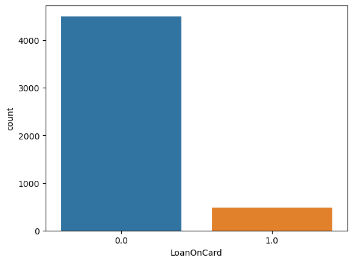

```python
sns.countplot(data=df,x='LoanOnCard')
```

#### Observations:

LoanOnCard coulmn has 3 values '0' '1' and 'NAN'.

There are 20 row with Null value, when compared to 5000 since the value is negligable we can remove the columns having the LoanOnCard value as null which would help in increasing the accurecy of model bulding

### 2.B. Check the percentage of missing values and impute if required.

```python
df. isnull().sum()/ len(df)*100
```

```
ID                     0.0
Age                    0.0
CustomerSince          0.0
HighestSpend           0.0
ZipCode                0.0
HiddenScore            0.0
MonthlyAverageSpend    0.0
Level                  0.0
Mortgage               0.0
Security               0.0
FixedDepositAccount    0.0
InternetBanking        0.0
CreditCard             0.0
LoanOnCard             0.4
dtype: float64
```

```python
df=df.dropna()
```

```python
df.shape
```

```
(4980, 14)
```

```python
df. isnull().sum()/ len(df)*100
```

```
ID                     0.0
Age                    0.0
CustomerSince          0.0
HighestSpend           0.0
ZipCode                0.0
HiddenScore            0.0
MonthlyAverageSpend    0.0
Level                  0.0
Mortgage               0.0
Security               0.0
FixedDepositAccount    0.0
InternetBanking        0.0
CreditCard             0.0
LoanOnCard             0.0
dtype: float64
```

### C. Check for unexpected values in each categorical variable and impute with best suitable value.

[Unexpected values means if all values in a feature are 0/1 then ‘?’, ‘a’, 1.5 are unexpected values which needs treatment ]

```python
for i in col:
    print(i , df[i].unique());
    print(i , len(df[i].unique()));
```

```
HiddenScore [1, 4, 3, 2]
Categories (4, int64): [1, 2, 3, 4]
HiddenScore 4
Level [3, 2, 1]
Categories (3, int64): [1, 2, 3]
Level 3
Security [0, 1]
Categories (2, int64): [0, 1]
Security 2
FixedDepositAccount [0, 1]
Categories (2, int64): [0, 1]
FixedDepositAccount 2
InternetBanking [0, 1]
Categories (2, int64): [0, 1]
InternetBanking 2
CreditCard [0, 1]
Categories (2, int64): [0, 1]
CreditCard 2
```

```python
from sklearn.impute import SimpleImputer
imputer = SimpleImputer(missing_values=np.nan, strategy='median')
imputer.fit(df.iloc[:,:-1])
imputed_data = imputer.transform(df.iloc[:,:-1].values)
df.iloc[:,:-1] = imputed_data
df.dropna(axis=0,inplace=True)
df.isnull().sum()
```

```
C:\Users\Bharath kumar s\anaconda3\lib\site-packages\sklearn\base.py:420: UserWarning: X does not have valid feature names, but SimpleImputer was fitted with feature names
  warnings.warn(
C:\Users\Bharath kumar s\AppData\Local\Temp\ipykernel_18996\1289818230.py:5: DeprecationWarning: In a future version, `df.iloc[:, i] = newvals` will attempt to set the values inplace instead of always setting a new array. To retain the old behavior, use either `df[df.columns[i]] = newvals` or, if co…
  df.iloc[:,:-1] = imputed_data
```

```
ID                     0
Age                    0
CustomerSince          0
HighestSpend           0
ZipCode                0
HiddenScore            0
MonthlyAverageSpend    0
Level                  0
Mortgage               0
Security               0
FixedDepositAccount    0
InternetBanking        0
CreditCard             0
LoanOnCard             0
dtype: int64
```

## 3. Data Preparation and model building:

### 3.A. Split data into X and Y.

[Recommended to drop ID & ZipCode. LoanOnCard is target Variable]

```python
X=df.drop(columns=['ID','ZipCode','LoanOnCard'])
Y=df['LoanOnCard']
```

```python
X.info()
```

```
<class 'pandas.core.frame.DataFrame'>
Int64Index: 4980 entries, 9 to 4999
Data columns (total 11 columns):
 #   Column               Non-Null Count  Dtype
---  ------               --------------  -----
 0   Age                  4980 non-null   float64
 1   CustomerSince        4980 non-null   float64
 2   HighestSpend         4980 non-null   float64
 3   HiddenScore          4980 non-null   float64
 4   MonthlyAverageSpend  4980 non-null   float64
 5   Level                4980 non-null   float64
 6   Mortgage             4980 non-null   float64
 7   Security             4980 non-null   float64
 8   FixedDepositAccount  4980 non-null   float64
 9   InternetBanking      4980 non-null   float64
 10  CreditCard           4980 non-null   float64
dtypes: float64(11)
memory usage: 466.9 KB
```

```python
print('X \n', X.sample(5),'\n')
print('Y \n',Y.sample(5))
```

```
X
        Age  CustomerSince  HighestSpend  HiddenScore  MonthlyAverageSpend  \
2390  33.0            9.0          41.0          3.0                  2.0
1172  49.0           24.0          45.0          3.0                  1.7
1690  26.0            1.0         102.0          1.0                  1.9
558   30.0            5.0          38.0          4.0                  2.0
2212  46.0           22.0          83.0          1.0                  2.7

      Level  Mortgage  Security  FixedDepositAccount  InternetBanking  \
2390    1.0     108.0       0.0                  0.0              1.0
1172    2.0       0.0       1.0                  0.0              1.0
1690    1.0       0.0       0.0                  0.0              0.0
558     2.0       0.0       1.0                  0.0              0.0
2212    1.0       0.0       0.0                  0.0              1.0

      CreditCard
2390         0.0
1172         0.0
1690         0.0
558          0.0
2212         0.0

Y
 1926    0.0
2612    0.0
4773    0.0
3442    0.0
4584    0.0
Name: LoanOnCard, dtype: float64
```

### 3.B.Split data into train and test. Keep 25% data reserved for testing.

```python
X_train, X_test, y_train, y_test = train_test_split(X,Y, test_size=0.25,random_state=10)
```

```python
print(df.shape)
print(X_train.shape)
print(X_test.shape)
```

```
(4980, 14)
(3735, 11)
(1245, 11)
```

### 3.C. Train a Supervised Learning Classification base model - Logistic Regression

```python
from sklearn.linear_model import LogisticRegression
logreg = LogisticRegression(solver='lbfgs', max_iter=10000)
logreg.fit(X_train, y_train)
logreg_pred = logreg.predict(X_test)

print('Accuracy on Training data:',logreg.score(X_train, y_train) )
print('Accuracy on Test data:',logreg.score(X_test, y_test) )
```

```
Accuracy on Training data: 0.9488621151271753
Accuracy on Test data: 0.9590361445783132
```

### 3.D. Print evaluation metrics for the model and clearly share insights

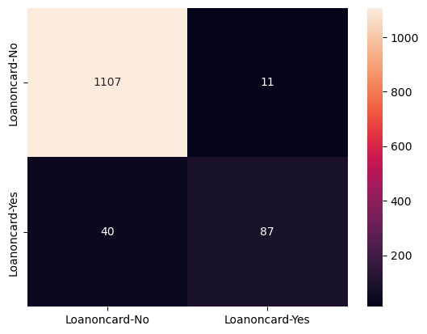

```python
cm =metrics.confusion_matrix(y_test, logreg_pred, labels=[0, 1])

df_cm = pd.DataFrame(cm, index = [i for i in ["Loanoncard-No","Loanoncard-Yes"]],
                  columns = [i for i in ["Loanoncard-No","Loanoncard-Yes"]])
sns.heatmap(df_cm, annot=True ,fmt='g')
plt.show()
```

```python
print("classification  Matrix:\n",classification_report(y_test,logreg_pred))
```

```
classification  Matrix:
               precision    recall  f1-score   support

         0.0       0.97      0.99      0.98      1118
         1.0       0.89      0.69      0.77       127

    accuracy                           0.96      1245
   macro avg       0.93      0.84      0.88      1245
weighted avg       0.96      0.96      0.96      1245
```

#### Observations:

The accurecy score for the model is 96% which looks to be accurate however the most of the data predicts non loan holders

The avrage Recall is 84% which indicates that the bank doesnt loose out on the customers who is capable of repaying the loan with the model

Precision score of the model which is ~>=90% is a good which helps the bank identifying the customers who can be ignored

### 3.E. Balance the data using the right balancing technique.

i. Check distribution of the target variable  
ii. Say output is class A : 20% and class B : 80%  
iii. Here you need to balance the target variable as 50:50.  
iv. Try appropriate method to achieve the same

```python
print(Y.value_counts())
```

```
0.0    4500
1.0     480
Name: LoanOnCard, dtype: int64
```

**As we can see the data is heavily skewed towards the nonloan holder.**  
**we need to install imblearn libray under which we can find Randomoversampler, Randomundersampler and SMOT(Synthetic Minority Oversampling Technique)**

```python
pip install imblearn
```

```python
from imblearn.over_sampling import RandomOverSampler
from imblearn.over_sampling import SMOTE
```

```python
smote=SMOTE(random_state=42)
x_s,y_s=smote.fit_resample(X,Y)
```

```python
print('After Balancing\n',y_s.value_counts())
```

```
After Balancing
 1.0    4500
0.0    4500
Name: LoanOnCard, dtype: int64
```

### 3.F.Again train the same previous model on balanced data.

```python
smote=SMOTE(random_state=42)
X_train_s,y_train_s=smote.fit_resample(X_train,y_train)
```

```python
logreg = LogisticRegression(solver='lbfgs', max_iter=10000)
logreg.fit(X_train_s, y_train_s)
logreg_pred_bd = logreg.predict(X_test)

print('Accuracy on balanced Training data:',logreg.score(X_train_s, y_train_s) )
print('Accuracy before balanced Training data:',logreg.score(X_train, y_train) )
print('Accuracy on Test data:',logreg.score(X_test, y_test) )
```

```
Accuracy on balanced Training data: 0.90612063867534
Accuracy before balanced Training data: 0.9001338688085676
Accuracy on Test data: 0.8867469879518072
```

### 3.G. Print evaluation metrics and clearly share differences observed.

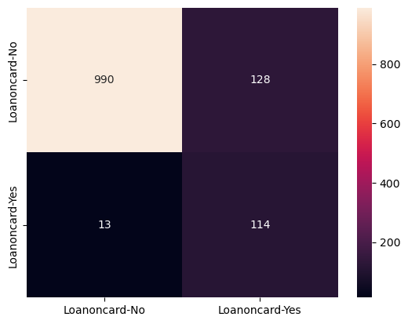

```python
cm =metrics.confusion_matrix(y_test, logreg_pred_bd, labels=[0, 1])

df_cm = pd.DataFrame(cm, index = [i for i in ["Loanoncard-No","Loanoncard-Yes"]],
                  columns = [i for i in ["Loanoncard-No","Loanoncard-Yes"]])
sns.heatmap(df_cm, annot=True ,fmt='g')
plt.show()
```

```python
print("classification  Matrix:\n",classification_report(y_test,logreg_pred))
```

```
classification  Matrix:
               precision    recall  f1-score   support

         0.0       0.97      0.99      0.98      1118
         1.0       0.89      0.69      0.77       127

    accuracy                           0.96      1245
   macro avg       0.93      0.84      0.88      1245
weighted avg       0.96      0.96      0.96      1245
```

#### Observations after Balancing the data using SMOT

Accurecy has dropped from 96% to 89%

## 4. Performance Improvement:

### A. Train a base model each for SVM, KNN.

### KNN

```python
NNH = KNeighborsClassifier(n_neighbors= 5 , weights = 'distance' )
NNH.fit(X_train, y_train)
predicted_labels_KNN = NNH.predict(X_test)
NNH.score(X_test, y_test)
```

```
0.9108433734939759
```

```
Confusion Matrix
```

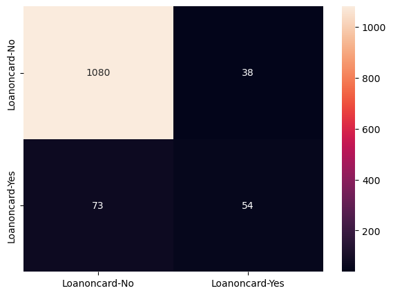

```python
print("Confusion Matrix")
cm=metrics.confusion_matrix(y_test, predicted_labels_KNN, labels=[0,1])

df_cm = pd.DataFrame(cm, index = [i for i in ["Loanoncard-No","Loanoncard-Yes"]],
                  columns = [i for i in ["Loanoncard-No","Loanoncard-Yes"]])
plt.figure(figsize = (7,5))
sns.heatmap(df_cm, annot=True,fmt='g')
plt.show()
```

```python
print("classification  Matrix:\n",classification_report(y_test,predicted_labels_KNN))
```

```
classification  Matrix:
               precision    recall  f1-score   support

         0.0       0.94      0.97      0.95      1118
         1.0       0.59      0.43      0.49       127

    accuracy                           0.91      1245
   macro avg       0.76      0.70      0.72      1245
weighted avg       0.90      0.91      0.90      1245
```

### SVM

```python
from sklearn.svm import SVC
```

```python
svc_model = SVC(C= .1, kernel='linear', gamma= 1)
svc_model.fit(X_train, y_train)

predicted_labels_SVM = svc_model .predict(X_test)
```

```python
print('SVM acurracy on Training data',svc_model.score(X_train, y_train))
print('SVM acurracy on Testing data',svc_model.score(X_test, y_test))
```

```
SVM acurracy on Training data 0.9515394912985274
SVM acurracy on Testing data 0.9550200803212852
```

```
Confusion Matrix
```

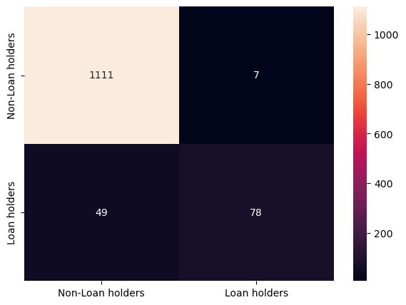

```python
print("Confusion Matrix")
cm=metrics.confusion_matrix(y_test, predicted_labels_SVM, labels=[0,1])

df_cm = pd.DataFrame(cm, index = [i for i in ["Non-Loan holders","Loan holders"]],
                  columns = [i for i in ["Non-Loan holders","Loan holders"]])
plt.figure(figsize = (7,5))
sns.heatmap(df_cm, annot=True,fmt='g')
```

```python
print("classification  Matrix:\n",classification_report(y_test,predicted_labels_SVM))
```

```
classification  Matrix:
               precision    recall  f1-score   support

         0.0       0.96      0.99      0.98      1118
         1.0       0.92      0.61      0.74       127

    accuracy                           0.96      1245
   macro avg       0.94      0.80      0.86      1245
weighted avg       0.95      0.96      0.95      1245
```

### 4.B.Tune parameters for each of the models wherever required and finalize a model.

### 4.C. Print evaluation metrics for final model.

```python
from sklearn import model_selection
```

```python
LR_model=LogisticRegression(solver='lbfgs', max_iter=10000)
KNN_model=KNeighborsClassifier(n_neighbors=11)
SVM_model = SVC()
```

```python
models = []
models.append(('LR', LR_model))
models.append(('KNN', KNN_model))
models.append(('SVM', SVM_model))
```

```python
results = []
names = []
scoring = 'accuracy'
for name, model in models:
    kfold = model_selection.KFold(n_splits=10)
    cv_results = model_selection.cross_val_score(model,  X,Y, cv=kfold, scoring=scoring)
    results.append(cv_results)
    names.append(name)
    msg = "%s: %f (%f)" % (name, cv_results.mean(), cv_results.std())
    print(msg)
```

```
LR: 0.950602 (0.008042)
KNN: 0.913052 (0.007831)
SVM: 0.907831 (0.011929)
```

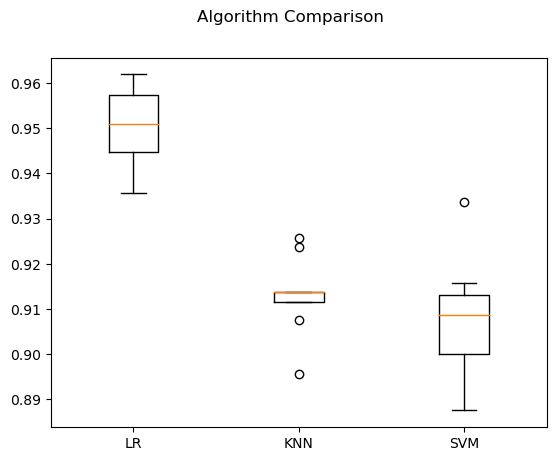

```python
fig = plt.figure()
fig.suptitle('Algorithm Comparison')
ax = fig.add_subplot(111)
plt.boxplot(results)
ax.set_xticklabels(names)
plt.show()
```

```python
models = []
models.append(('LR', LR_model))
models.append(('KNN', KNN_model))
models.append(('SVM', SVM_model))
results = []
names = []
scoring = 'accuracy'
for name, model in models:
    kfold = model_selection.StratifiedKFold(n_splits=20)
    cv_results = model_selection.cross_val_score(model,  X,Y, cv=kfold, scoring=scoring)
    results.append(cv_results)
    names.append(name)
    msg = "%s: %f (%f)" % (name, cv_results.mean(), cv_results.std())
    print(msg)
```

```
LR: 0.951205 (0.012654)
KNN: 0.913454 (0.011946)
SVM: 0.908635 (0.006942)
```

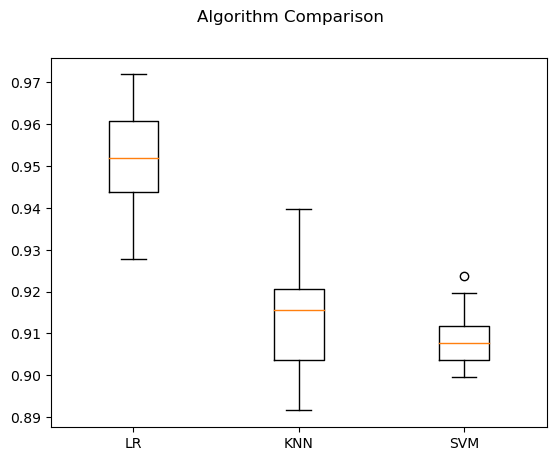

```python
fig = plt.figure()
fig.suptitle('Algorithm Comparison')
ax = fig.add_subplot(111)
plt.boxplot(results)
ax.set_xticklabels(names)
plt.show()
```

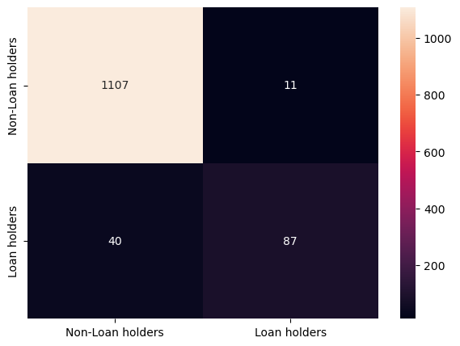

```python
cm = metrics.confusion_matrix(y_test, logreg_pred, labels=[0, 1])

df_cm = pd.DataFrame(cm, index = [i for i in ["Non-Loan holders","Loan holders"]],
                  columns = [i for i in ["Non-Loan holders","Loan holders"]])
plt.figure(figsize = (7,5))
sns.heatmap(df_cm, annot=True ,fmt='g')
plt.show()
```

### 4.D. Share improvement achieved from base model to final model.

#### Observations:

As observered in the box plots the Logistict regression seems to be the best model for the data provided.

The False Positive rate in Logistic regression is close to accurate.

#### Improvments:

To Improve accuraccy in individual marketing few more attributes like customers Accomadation (Reneted or own house),Vehicle's owned(If available) can be collected.

To make the prediction more accurate Customers occupation(salleried or self-employed) can be collected